DS 6030 | Fall 2023 | University of Virginia

# Homework #7: Clustering

Author

**Jacqui Unciano**

Published

October 24, 2023

This is an **independent assignment**. Do not discuss or work with classmates.

# Required R packages and Directories

```r
data.dir = 'https://mdporter.github.io/DS6030/data/' # data directory
library(mclust)    # for model-based clustering
library(mixtools)  # for poisson mixture mode
library(tidyverse) # functions for data manipulation
```

# Problem 1: Customer Segmentation with RFM (Recency, Frequency, and Monetary Value)

RFM analysis is an approach that some businesses use to understand their customers’ activities. At any point in time, a company can measure how recently a customer purchased a product (Recency), how many times they purchased a product (Frequency), and how much they have spent (Monetary Value). There are many ad-hoc attempts to segment/cluster customers based on the RFM scores (e.g., here is one based on using the customers’ rank of each dimension independently: https://joaocorreia.io/blog/rfm-analysis-increase-sales-by-segmenting-your-customers.html). In this problem you will use the clustering methods we covered in class to segment the customers.

The data for this problem can be found here: <https://mdporter.github.io/DS6030/data//RFM.csv>. Cluster based on the Recency, Frequency, and Monetary value columns.

**Solution**

```r
data = read.csv("C:/Users/jacqu/Downloads/RFM.csv")
head(data)
```

```
  id Recency Frequency Monetary
1  1     139        13     1147
2  2     447        10      939
3  3     164         7      690
4  4     120        11     1191
5  5     213        13      996
6  6     111         9     1005
```

## a. Implement hierarchical clustering.

- Describe any pre-processing steps you took (e.g., scaling, distance metric)
- State the linkage method you used with justification.
- Show the resulting dendrogram
- State the number of segments/clusters you used with justification.
- Using your segmentation, are customers 1 and 100 in the same cluster?

**Solution**

```r
## scaling the data
dat = data %>%
  select(Recency, Frequency, Monetary) %>%
  scale() %>%
  as_tibble()
head(dat)
```

```
# A tibble: 6 × 3
  Recency Frequency Monetary
    <dbl>     <dbl>    <dbl>
1  -0.323    1.02    0.610
2   2.01     0.0593  0.00955
3  -0.134   -0.897  -0.709
4  -0.467    0.378   0.737
5   0.237    1.02    0.174
6  -0.535   -0.260   0.200
```

```r
## distance calulated with euclidean method, and centroid approach with the number of
## points taken into consideration (aka ward)
dis = dist(dat, method="euclidean")
hc = hclust(dis, method="ward.D2")
```

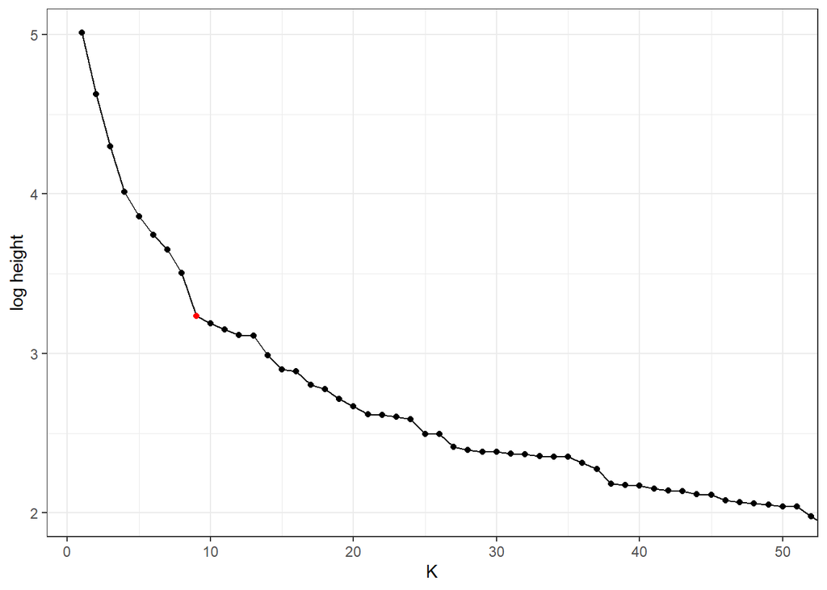

```r
tibble(height = log(hc$height), K = row_number(-height)) %>%
  ggplot(aes(K, height)) +
  geom_line() +
  geom_point(aes(color = ifelse(K == 9, "red", "black"))) +
  scale_color_identity() +
  coord_cartesian(xlim=c(1, 50), y=c(2, NA)) +
  labs(y = "log height")
```

```r
cutree(hc, k=9) %>% table()
```

```
.
   1    2    3    4    5    6    7    8    9
1616 1058 1347  923 2115 1923  356  297  365
```

```r
print(cutree(hc, k=9)[1])
```

```
[1] 1
```

```r
print(cutree(hc, k=9)[100])
```

```
[1] 2
```

I first scaled the data and then used the ward linkage method because it takes into account the number of points in each cluster, which I like and I think is better than simple centroid approach. Because of the elbow plot, I chose K=9, which makes obs 1 and 100 not in the same cluster.

## b. Implement k-means.

- Describe any pre-processing steps you took (e.g., scaling)
- State the number of segments/clusters you used with justification.
- Using your segmentation, are customers 1 and 100 in the same cluster?

**Solution**

```r
Kmax = 20
SSE = numeric(Kmax)
for(k in 1:Kmax){
  km = kmeans(dat, centers=k, nstart=25)
  SSE[k] = km$tot.withinss # get SSE
}
```

[output not shown]

[output cut: 8 more lines]

[output not shown]

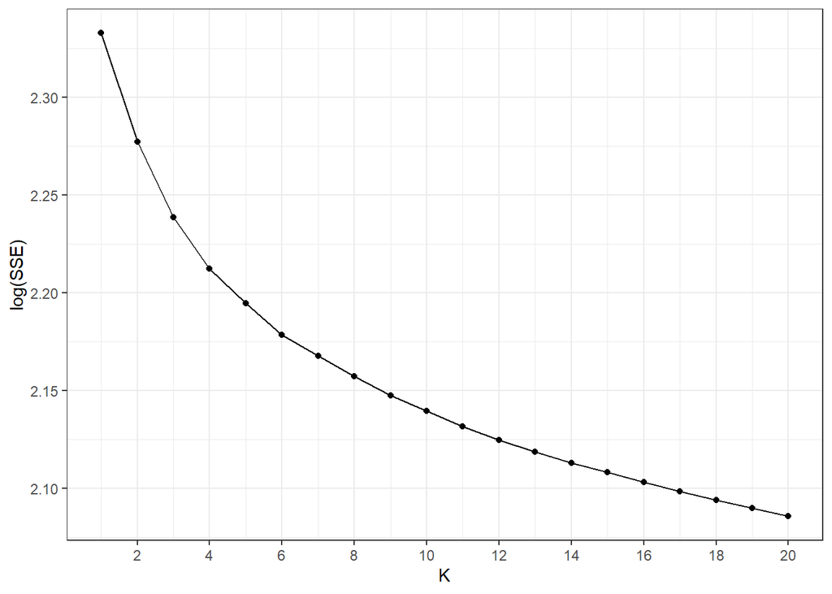

```r
results = tibble(K = 1:Kmax, SSE = log(SSE))

results %>% ggplot(aes(K, log(SSE))) +
  geom_point() + geom_line() +
  scale_x_continuous(breaks=seq(0, 100, by=2))
```

```r
km = kmeans(dat, centers=9, nstart=25) # choose K=9
table(est=km$cluster)
```

```
est
   1    2    3    4    5    6    7    8    9
1395  681  663 2022  619  843 1381  964 1432
```

```r
print(km$cluster[1])
```

```
[1] 1
```

```r
print(km$cluster[100])
```

```
[1] 7
```

## c. Implement model-based clustering

- Describe any pre-processing steps you took (e.g., scaling)
- State the number of segments/clusters you used with justification.
- Describe the best model. What restrictions are on the shape of the components?
- Using your segmentation, are customers 1 and 100 in the same cluster?

**Solution**

```r
mix = Mclust(dat, verbose=FALSE)
summary(mix)
```

```
----------------------------------------------------
Gaussian finite mixture model fitted by EM algorithm
----------------------------------------------------

Mclust VVV (ellipsoidal, varying volume, shape, and orientation) model with 8
components:

 log-likelihood     n df    BIC    ICL
         -32963 10000 79 -66653 -76787

Clustering table:
   1    2    3    4    5    6    7    8
2089 1093 2229 1222  514  957  909  987
```

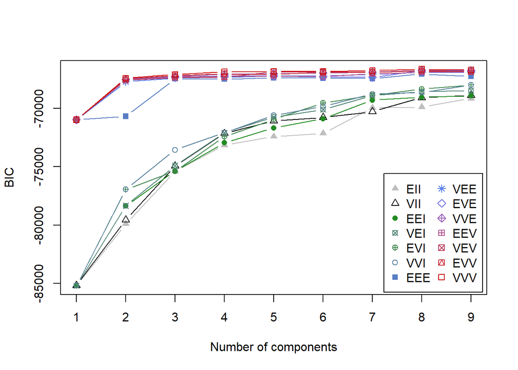

```r
plot(mix, what="BIC")
```

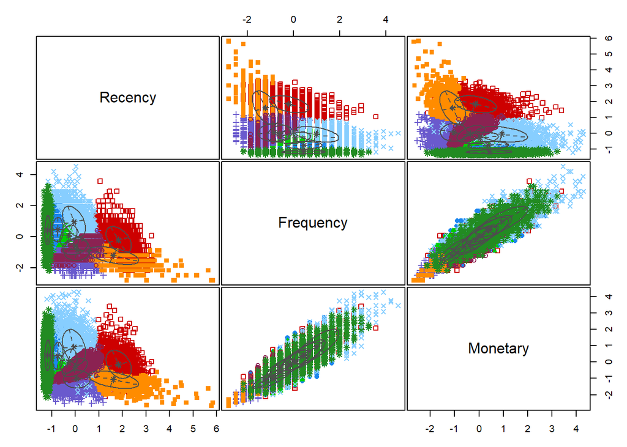

```r
plot(mix, what="classification")
```

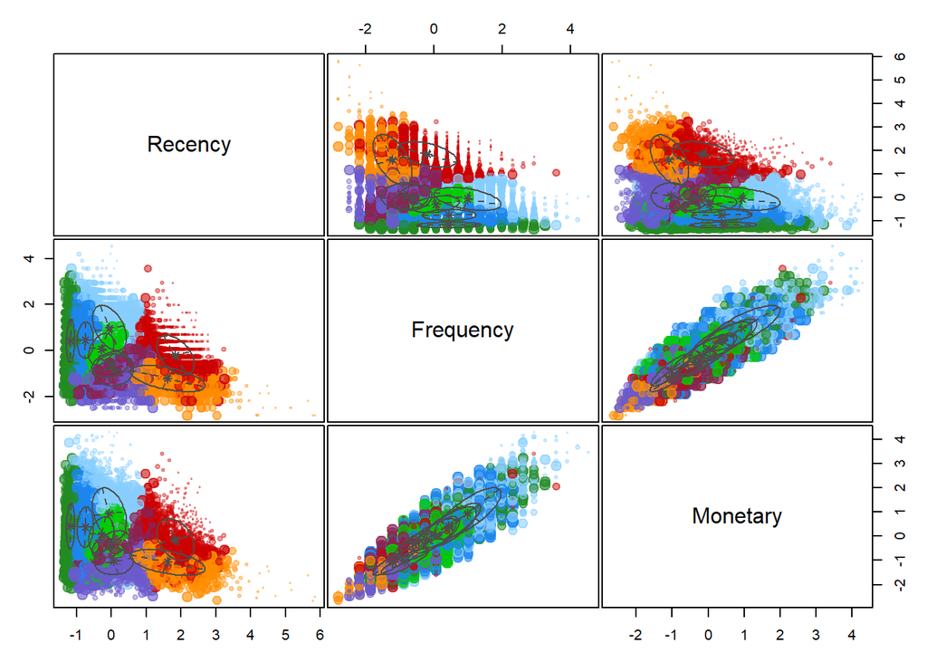

```r
plot(mix, what="uncertainty")
```

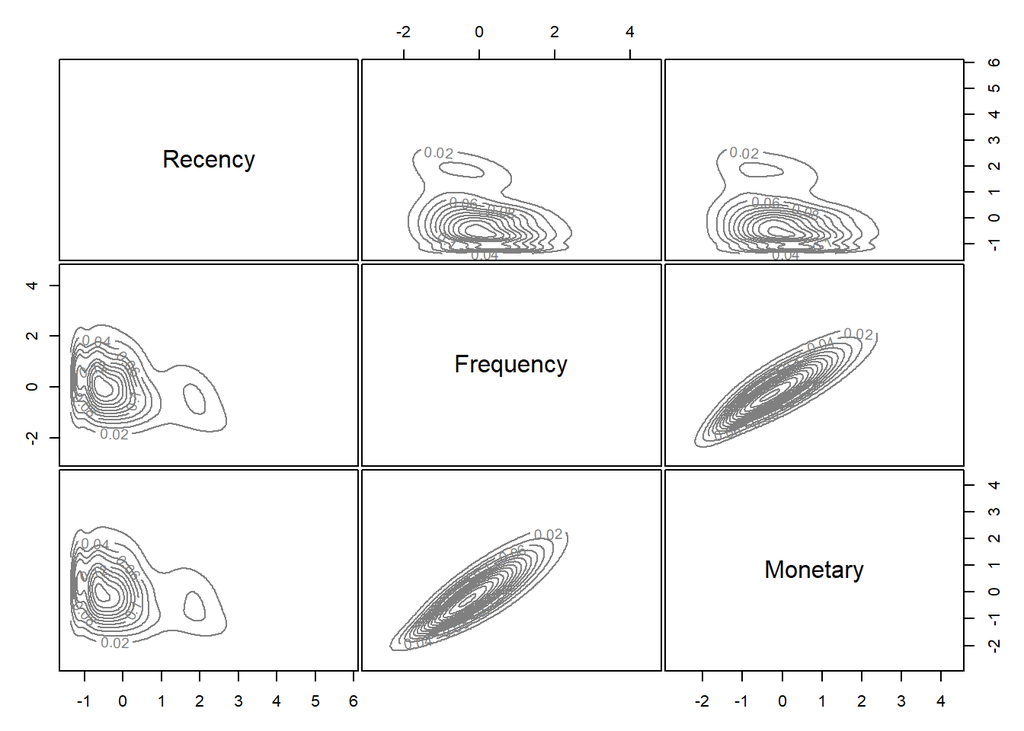

```r
plot(mix, what="density")
```

```r
print(mix$classification[1])
```

```
[1] 3
```

```r
print(mix$classification[100])
```

```
[1] 4
```

## d. Discussion of results

Discuss how you would cluster the customers if you had to do this for your job. Do you think one model would do better than the others?

**Solution**

I don’t know if this is possible, but I would cluster it with a 3D model. Right now, it seems as though the clusters are based on a pairing RF and FM and MR, but I would like to see clustering based on RFM, which I think would be a better model to see which customers are super loyal.

I do think that if we’re wondering which customers just spend the most money and frequently/moderately frequently would be a good way to cluster the data too. In this case, I think 8-9 clusters would be good because it’s supported by both the hierarchical clustering method and the model-based clustering method.

# Problem 2: Poisson Mixture Model

The pmf of a Poisson random variable is:
$$\begin{align*}
f_k(x; \lambda_k) = \frac{\lambda_k^x e^{-\lambda_k}}{x!}
\end{align*}$$

A two-component Poisson mixture model can be written:
$$\begin{align*}
f(x; \theta) = \pi \frac{\lambda_1^x e^{-\lambda_1}}{x!} + (1-\pi) \frac{\lambda_2^x e^{-\lambda_2}}{x!}
\end{align*}$$

## a. Model parameters

What are the parameters of the model?

**Solution**

$\theta = (\lambda_1, \lambda_2, \pi)$

## b. Log-likelihood

Write down the log-likelihood for $n$ independent observations ($x_1, x_2, \ldots, x_n$).

**Solution**

$f(\Sigma x_i; \theta) = \pi \frac{\lambda_1^\Sigma x_i e^{-\lambda_1}}{\Sigma x_i!} + (1-\pi) \frac{\lambda_2^\Sigma x_i e^{-\lambda_2}}{\Sigma x_i!}$ $lnL(\theta) = \Sigma_{i=1}^{n}ln(\pi \frac{\lambda_1^\Sigma x_i e^{-\lambda_1}}{\Sigma x_i!} + (1-\pi) \frac{\lambda_2^\Sigma x_i e^{-\lambda_2}}{\Sigma x_i!})$

## c. Updating the responsibilities

Suppose we have initial values of the parameters. Write down the equation for updating the *responsibilities*.

**Solution**

$r_{ik} = \frac{P(X|K=k, \theta_k) \pi_k}{\Sigma_{j=1}P(X|K=j, \theta_k) \pi_j}$

## d. Updating the model parameters

Suppose we have responsibilities, $r_{ik}$ for all $i=1, 2, \ldots, n$ and $k=1,2$. Write down the equations for updating the parameters.

**Solution**

$r_{i1} = \frac{P(X_i|K=1, \theta_1) \pi_1}{P(X_i|K=1, \theta_1) \pi_1 + P(X_i|K=2, \theta_2) \pi_2}$ $r_{i2} = \frac{P(X_i|K=2, \theta_2) \pi_2}{P(X_i|K=1, \theta_1) \pi_1 + P(X_i|K=2, \theta_2) \pi_2}$

## e. Fit a two-component Poisson mixture model

Fit a two-component Poisson mixture model. Report the estimated parameter values and show a plot of the estimated mixture pmf for the following data:

```r
#-- Run this code to generate the data
set.seed(123)             # set seed for reproducibility
n = 200                   # sample size
z = sample(1:2, size=n, replace=TRUE, prob=c(.25, .75)) # sample the latent class
theta = c(8, 16)          # true parameters
y = ifelse(z==1, rpois(n, lambda=theta[1]), rpois(n, lambda=theta[2]))
```

- Note: The function `poisregmixEM()` in the R package `mixtools` is designed to estimate a mixture of *Poisson regression* models. We can still use this function for our problem of pmf estimation if it is recast as an intercept-only regression. To do so, set the $x$ argument (predictors) to `x = rep(1, length(y))` and `addintercept = FALSE`.
  - Look carefully at the output from this model. The `beta` values (regression coefficients) are on the log scale.

**Solution**

```r
set.seed(123)
x = rep(1, length(y))
#-- Fit K=2 component mixture model
PMM = mixtools::poisregmixEM(x=x, y=y, addintercept = FALSE, k=2) # use poisregmixEM()
```

```
number of iterations= 68
```

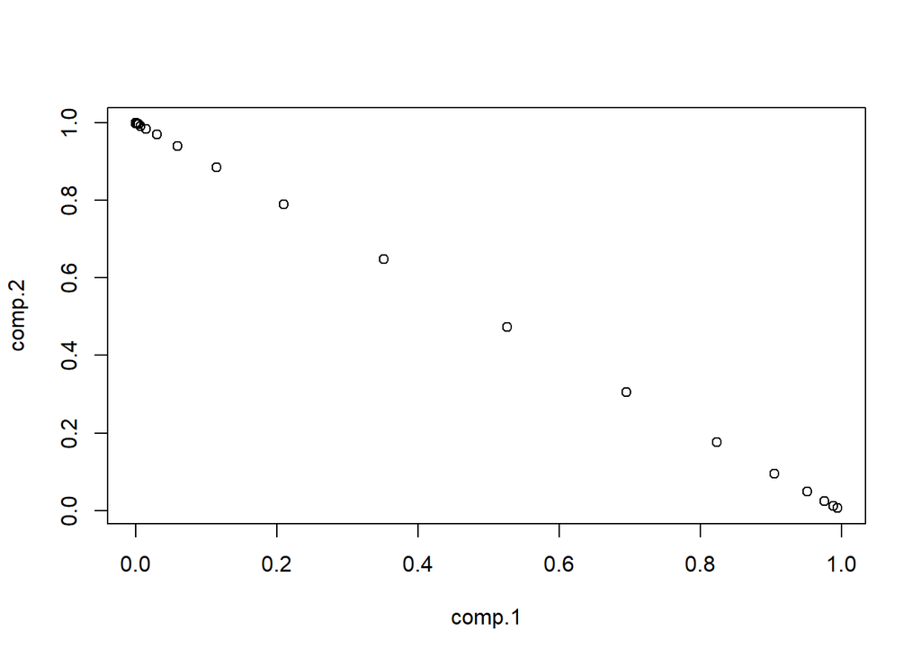

```r
#-- Plot 95% contour
plot(PMM$posterior, density=TRUE, alpha=0.05)
```

## f. **2 pts Extra Credit** EM from scratch

Write a function that estimates this two-component Poisson mixture model using the EM approach. Show that it gives the same result as part *e*.

- Note: you are not permitted to copy code. Write everything from scratch and use comments to indicate how the code works (e.g., the E-step, M-step, initialization strategy, and convergence should be clear).
- Cite any resources you consulted to help with the coding.

**Solution**